# Introductions ("Who even is this person?")

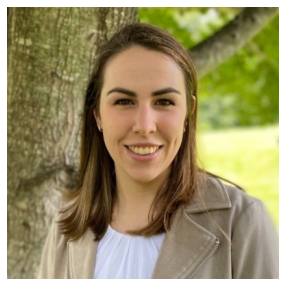

```python
# A first look at something matplotlib can do
img = mpimg.imread('LinkedIn Headshot.jfif')
fig = plt.figure(figsize=(5,5))
plt.axis('off')
plt.imshow(img)
plt.show()
```

Email: emily.lynn@slalom.com - Feel free to email me and tell me a little about yourself and how you ended up here at LaunchCode!

# Plan for Tonight

1. **Why** data viz is important
2. **What** makes a good visualization
3. **How** to choose a visualization type
4. Matplotlib and seaborn

We aren't going to go straight to the code...and that is on purpose! The 'Why' behind data viz is just as important, if not more important, than the 'How'.

*Feel free to interrupt me at ANY point to ask questions, make comments, etc. There are no stupid questions, and everyone learns better when I'm not just talking at you while you get sleepy :)*

# What's the Big Deal with Data Visualization?

There are two different reasons that you may use data visualization:

- Exploratory Data Analysis (EDA) and data cleaning - trying to understand the data for yourself
- Communicating results of your analytics work to teammates or business stakeholders

Some quotes I really love about data visualization:

> "The purpose of visualization is insight, not pictures." - Ben A. Shneiderman

> "Data visualization is the language of decision making. Good charts effectively convey information. Great charts enable, inform, and improve decision making" - Dante Vitagliano

> "The effectiveness of data visualization can be gauged by its simplicity, relevancy, and its ability to hold the user's hand during their data discovery journey." - Jagat Saikia

# So Visualization is Important, How Do I Do It Well?

### Do

- Make visualizations!
- Make visualizations that are clean and crisp (color is important here)
- Stick to the most important information
- Ask yourself why you are making this chart, who the audience is, and what the story is that you are trying to tell
- Experiment with different chart types to help you decide which one tells the story best

### Don't

- Convey your insights as just numbers and words
- Make visualization overly busy
- Show as much information as possible, everything that you found out about the data
- Assume whoever is looking at you data knows everything that you do
- Use the first chart type that comes to mind

# What Makes a Good Visualization?

There are a couple of different ways to think about it...pick one (or a combo) that works best for you.

# The McCandless Method

David McCandles is an author and creator of the site *informationisbeautiful.net* and the creator of some really beautiful published visualizations. He defines 4 elements that are necessary for a "good" visualization (see *informationisbeautiful.net/visualizations/what-makes-a-good-data-visualization/*) :

1. **Information** - The data! It should be accurate, consistent, and honest (no fudging numbers)
2. **Story** - The concept. Why is what you are trying to say relevant and meaningful? Why should the audience care?
3. **Goal** - The 'Why' behing the picture. What is the purpose?
4. **Visual Form** - The structure of your viz. Is it easy to interpret? Is it clear?

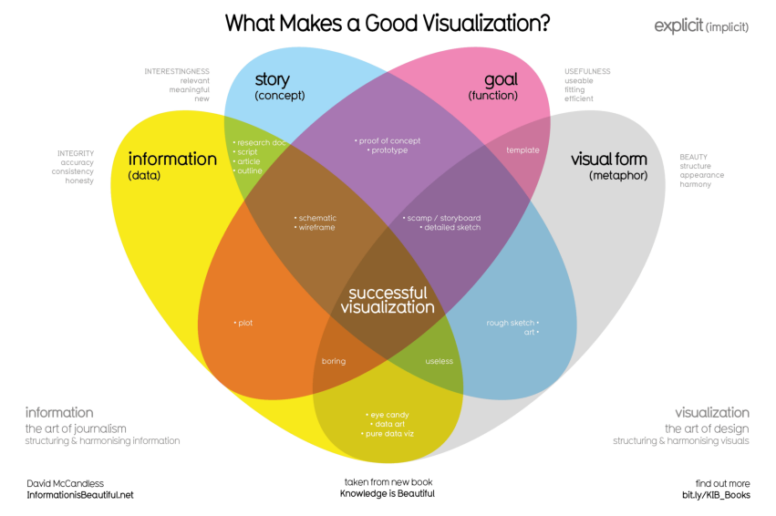

```python
img = mpimg.imread('McCandles What Makes a Good Visualization.png')
fig = plt.figure(figsize=(15,15))
plt.axis('off')
plt.imshow(img)
plt.show()
```

# Kaiser Fung's Junk Charts Trifecta

This comes from a website that looks at examples of what NOT to do. Check it out at *junkcharts.typepad.com/junk_charts/*. He breaks it down into 3 questions you should ask yourself:

1. What is the practical question?
2. What does the data say?
3. What does the visual say?

# Questions?

[figure not shown]

# Basic Chart Types and When to Use Them

- Scatter Plot
- Line Chart
- Bar Chart
- Histogram
- Pie Chart

# Scatter Plot

Shows the relationships between different variables (usually 2 unless size or color of the marker is used as the 3rd variable)

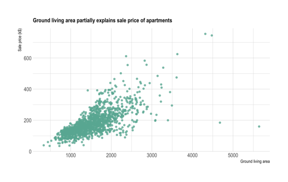

```python
img = mpimg.imread('Scatterplot Example.png')
fig = plt.figure(figsize=(10,10))
plt.axis('off')
plt.imshow(img)
plt.show()
```

*Chart from https://www.data-to-viz.com/graph/scatter.html*

### Do

- Show subgroups if present

### Don't

- Don't overplot. Some scatter plots can just get too busy to be useful

# Line Chart

Used to track changes over periods of time. Can be used to compare changes over the same period of time for more than one group.

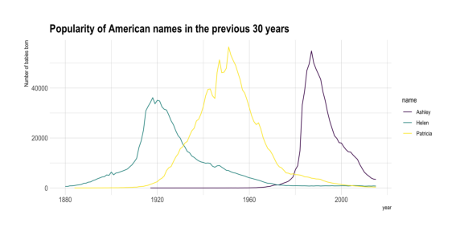

```python
img = mpimg.imread('Line Graph Example.png')
fig = plt.figure(figsize=(10,10))
plt.axis('off')
plt.imshow(img)
plt.show()
```

*Chart from https://www.data-to-viz.com/graph/line.html*

### Do

- If you aren't starting you y-axis at 0, make sure to explicitely call it out so as not to be misleading

### Don't

- Don't include too many lines on the same chart. Keep it readable.
- Don't use dual axis. This is often misleading.
- Use grid lines unless it is actually helpful. They often add unnecessary busyness to the visual

# Column/Bar Chart

Compare and contrast two or more categorical values. Careful, this is not the same thing as a histogram which shows the distribution of variables.

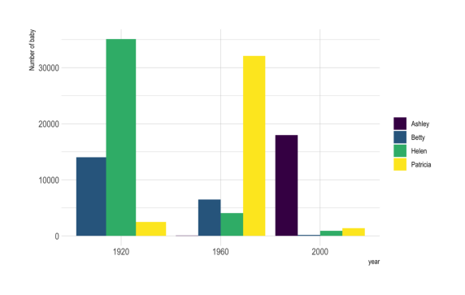

```python
img = mpimg.imread('Bar Chart Example.png')
fig = plt.figure(figsize=(10,10))
plt.axis('off')
plt.imshow(img)
plt.show()
```

*Chart from https://www.data-to-viz.com/graph/barplot.html*

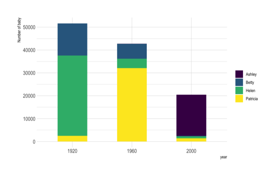

```python
img = mpimg.imread('Stacked Bar Chart Example.png')
fig = plt.figure(figsize=(10,10))
plt.axis('off')
plt.imshow(img)
plt.show()
```

*Chart from https://www.data-to-viz.com/graph/barplot.html*

### Do

- Keep the order of the bars the same if you are showing the same bars multiple times

### Don't

# Histogram

Used to see the distribution of one (or a few) variables

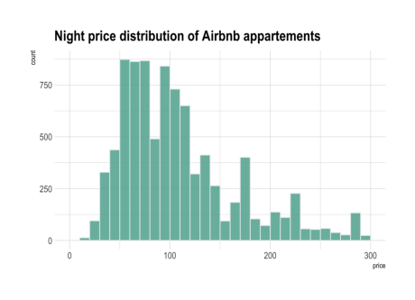

```python
img = mpimg.imread('Histogram Example.png')
fig = plt.figure(figsize=(8,8))
plt.axis('off')
plt.imshow(img)
plt.show()
```

*Chart from https://www.data-to-viz.com/graph/histogram.html*

### Do

- Try out different bin sizes

### Don't

- Don't compare more than 3 or 4 variables on the same chart - gets too busy
- Don't use unequal bin widths, this skews the data

# Pie Chart

Used to show different segments that are a part of a whole.

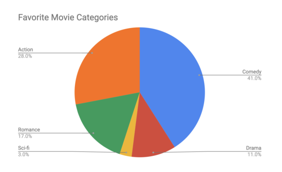

```python
img = mpimg.imread('Pie Chart Example.png')
fig = plt.figure(figsize=(10,10))
plt.axis('off')
plt.imshow(img)
plt.show()
```

*Chart from https://www.coursera.org/learn/visualize-data/supplement/j9Wdl/the-wonderful-world-of-visualizations*

### Do

- Avoid pie charts in general. Humans are bad at reading angles, and a better story can usually be told with bar plots.

### Don't

- Use 3D features (really you should probably never use 3D features in plots)
- Have segments that don't sum to 100 or the 'whole population'

# Choosing a Chart Type

Some example questions to ask youself:

- What type of data do you have? (e.g numeric, categoric, time series, etc.)
- How many variables do you have?
- Are you measuring changes over time?
- Are there relationships between the data that need to be shown?
- How many data points need to be shown?
- Is the data ordered?

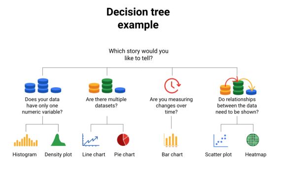

```python
img = mpimg.imread('Visualization Decision Tree.png')
fig = plt.figure(figsize=(10,10))
plt.axis('off')
plt.imshow(img)
plt.show()
```

Visual from *https://www.coursera.org/learn/visualize-data/supplement/XvN2U/data-grows-on-decision-trees*

# Additional Resources

I LOVE the way these sites walk through the process of choosing a graph. They also show examples of some less common graph types (boxplot, violin plot, correlogram, etc.)

- https://www.data-to-viz.com/ - Gives tips for each type of graph, as well as code snippets to make them
- https://www.datavizcatalogue.com - Allows you to search for graph types based on what you are trying to show
- [Youtube video: Which is the best chart: Selecting among 14 types of charts Part I](https://www.youtube.com/watch?v=C07k0euBpr8) - There is a part 2 as well

# Let's Practice...

*(All examples taken from https://www.polymersearch.com/blog/10-good-and-bad-examples-of-data-visualization)*

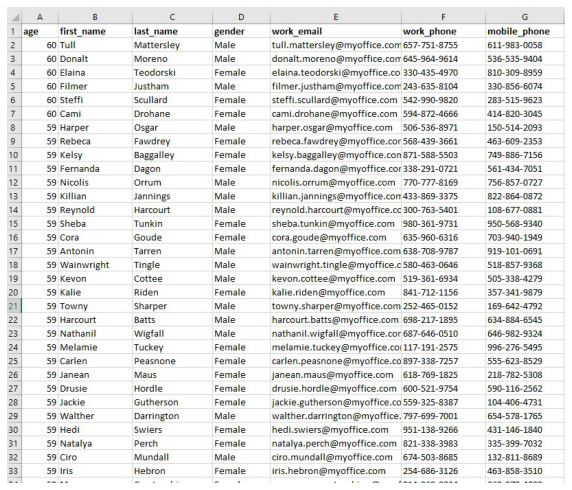

```python
img = mpimg.imread('Bad Table Example.jpg')
fig = plt.figure(figsize=(10,10))
plt.axis('off')
plt.imshow(img)
plt.show()
```

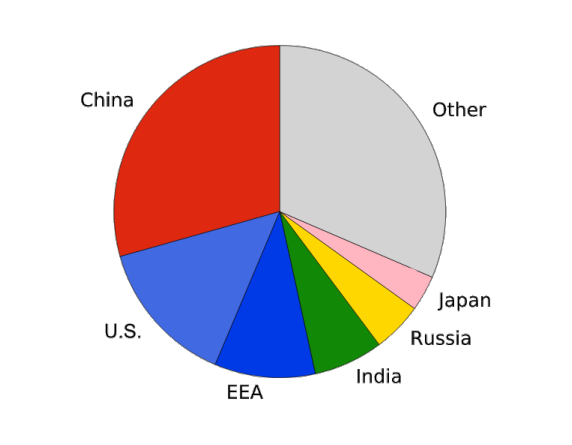

```python
img = mpimg.imread('Bad Pie Chart Example.png')
fig = plt.figure(figsize=(10,10))
plt.axis('off')
plt.imshow(img)
plt.show()
```

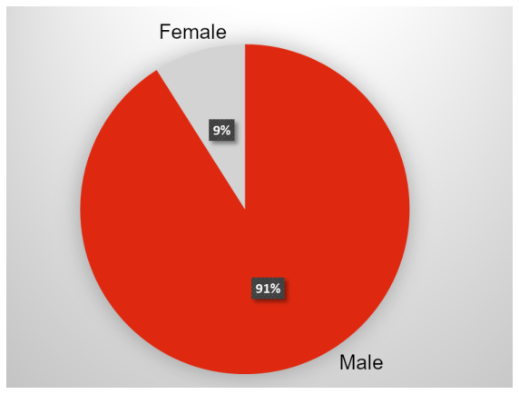

```python
img = mpimg.imread('Good Pie Chart Example.png')
fig = plt.figure(figsize=(10,10))
plt.axis('off')
plt.imshow(img)
plt.show()
```

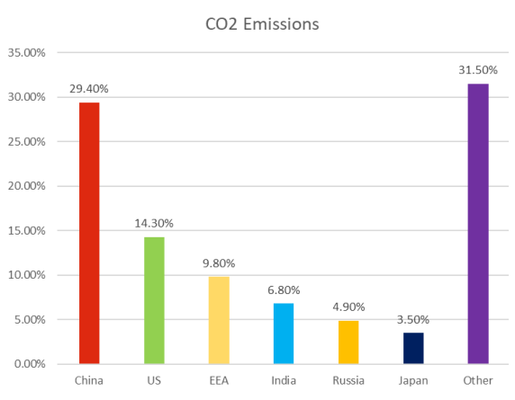

```python
img = mpimg.imread('Bad Bar Chart Example.png')
fig = plt.figure(figsize=(10,10))
plt.axis('off')
plt.imshow(img)
plt.show()
```

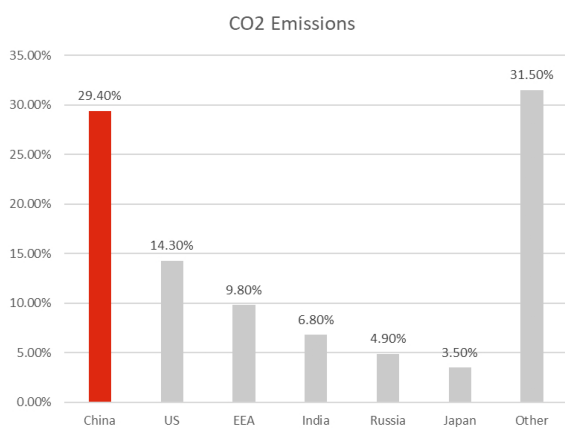

```python
img = mpimg.imread('Good Bar Chart Example.png')
fig = plt.figure(figsize=(10,10))
plt.axis('off')
plt.imshow(img)
plt.show()
```

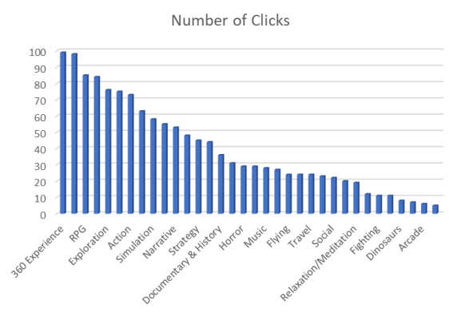

```python
img = mpimg.imread('Another Bad Bar Chart Example.png')
fig = plt.figure(figsize=(10,10))
plt.axis('off')
plt.imshow(img)
plt.show()
```

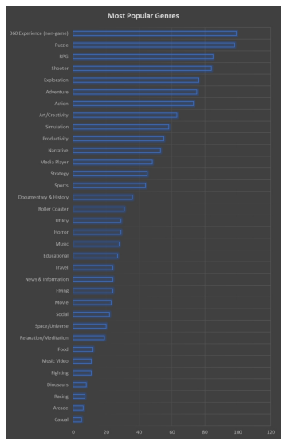

```python
img = mpimg.imread('Another Good Bar Chart Example.png')
fig = plt.figure(figsize=(10,10))
plt.axis('off')
plt.imshow(img)
plt.show()
```

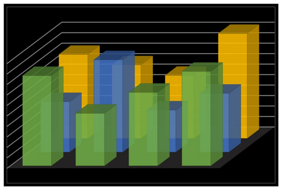

```python
img = mpimg.imread('Yet Another Bad Bar Chart Example.png')
fig = plt.figure(figsize=(10,10))
plt.axis('off')
plt.imshow(img)
plt.show()
```

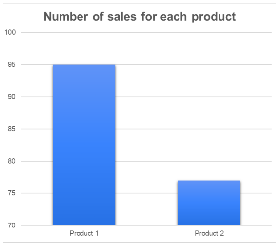

```python
img = mpimg.imread('And Another Bad Bar Chart Example.png')
fig = plt.figure(figsize=(10,10))
plt.axis('off')
plt.imshow(img)
plt.show()
```

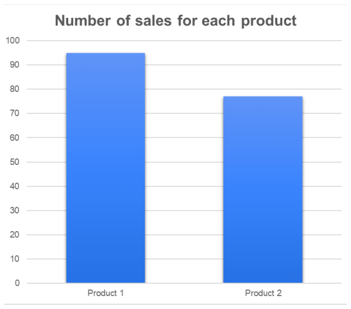

```python
img = mpimg.imread('And Another Good Bar Chart Example.png')
fig = plt.figure(figsize=(10,10))
plt.axis('off')
plt.imshow(img)
plt.show()
```

# 5 Min Break

[figure not shown]

# Matplotlib

Yes - matplotlib can be a little confusing. If you use the internet for reference (which you totally should by the way) then you may have already seen by now that there are often several ways to do things. There are actually two main ways:

- Object-oriented
- Pyplot interfaces

Terms to remember:

**Figures** : The whole 'canvas' where you create your visualizations. A single figure can contain one or more Axes.

**Axes** : An area where points can be specified in terms of x-y coordinates (basically an area where a specific plot will be). Usually includes two or more Axis. Most objects are assigned to a certain axes. (Yes it's confusing that Axes and Axis are so similar, don't ask me why they did this)

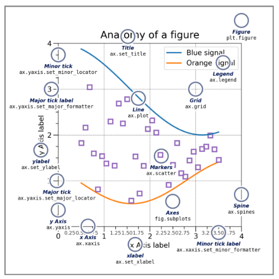

```python
img = mpimg.imread('The Anatomy of a Figure.png')
fig = plt.figure(figsize=(10,10))
plt.axis('off')
plt.imshow(img)
plt.show()
```

*Picture from https://matplotlib.org/stable/tutorials/introductory/usage.html*

# Object-Oriented (Flexible and Customizable)

This is the approach where you explicitely create Figures and Axes (the 'objects'), and then call methods on them. This is the way the Matplotlib suggests for general use because it can be used to make more complicated plots, functions, and scripts. It is more flexible, and you have more control over every part of your visualization

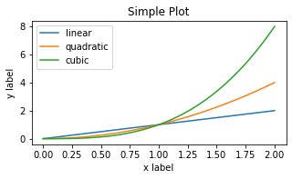

```python
x = np.linspace(0, 2, 100)  # Sample data.

# Note that even in the OO-style, we use `.pyplot.figure` to create the Figure.
fig, ax = plt.subplots(figsize=(5, 2.5))
ax.plot(x, x, label='linear')  # Plot some data on the axes.
ax.plot(x, x**2, label='quadratic')  # Plot more data on the axes...
ax.plot(x, x**3, label='cubic')  # ... and some more.
ax.set_xlabel('x label')  # Add an x-label to the axes.
ax.set_ylabel('y label')  # Add a y-label to the axes.
ax.set_title("Simple Plot")  # Add a title to the axes.
ax.legend();  # Add a legend.
```

# PyPlot Interface (Quick and Simple)

Rely on pyplot to automatically create and manage the figures and axes, and use pyplot functions for plotting

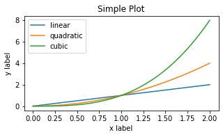

```python
x = np.linspace(0, 2, 100)  # Sample data.

plt.figure(figsize=(5, 2.5))
plt.plot(x, x, label='linear')  # Plot some data on the (implicit) axes.
plt.plot(x, x**2, label='quadratic')  # etc.
plt.plot(x, x**3, label='cubic')
plt.xlabel('x label')
plt.ylabel('y label')
plt.title("Simple Plot")
plt.legend();
```

# Customizing Your Plot

```python
dataset1, dataset2, dataset3, dataset4 = np.random.randn(4, 100) # make 4 random data sets
```

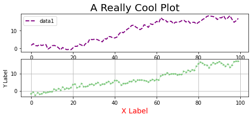

```python
# Note: these are NOT examples of well-created plots, just showing how to customize things with matplotlib
fig, ax = plt.subplots(2, 1, figsize=(8, 3))
x = np.arange(len(dataset1))
ax[0].plot(x, np.cumsum(dataset1), color='purple', linewidth=2, linestyle='--', label='data1') # specify the color as a work, and the linestyle
ax[1].plot(x, np.cumsum(dataset2), marker='>', color='C0', markersize=3, linewidth=.5, label='data2') # specify the color as a colorcode, add markers
ax[1].set_xlabel('X Label', fontsize=14, color='red')
ax[1].set_ylabel('Y Label')
ax[0].set_title('A Really Cool Plot', fontsize=20)
ax[1].grid(True)
ax[1].annotate("Look here!", xy=(20,-15), xytext= (25, -9), arrowprops=dict(facecolor='black', shrink=0.05))
ax[0].legend() # add the legend, which includes the labels specified for the plots
plt.show()
```

# Questions?

[figure not shown]

# Seaborn

Seaborn is a library that was built on top of matplotlib for the purpose of making plots 'easier' to make and more visually appealing out-of-the-box. This means that it is pretty simple to use both seaborn and matplotlib together. Think of seaborn as giving you a simple and quick way to initially create the graph you want with some high level customizations available, and then you can use matplotlib to customize it further to get it exactly how you want.

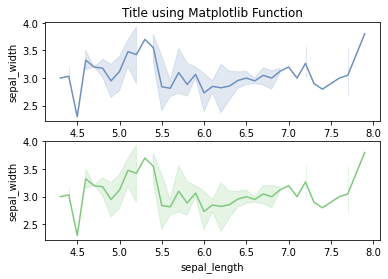

```python
# importing packages
import seaborn as sns
import matplotlib.pyplot as plt
# loading dataset
data = sns.load_dataset("iris") # anything that starts with 'sns' is seaborn functionality
# Making one plot
sns.set_palette("vlag") # quick way to set the colors and 'make it pretty'
plt.subplot(211) # defines where we want out subplots to be - '2' subplot, in '1' column, and this is the first (1) plot
plt.title('Title using Matplotlib Function') # anything that starts with 'plt' is matplotlib functionality
sns.lineplot(x="sepal_length", y="sepal_width", data=data)
plt.plot()
# Making another plot
sns.set_palette("Accent") # quick way to set all colors to a certain palette
plt.subplot(212)
sns.lineplot(x="sepal_length", y="sepal_width", data=data)
plt.plot()
plt.show()
```